# Survey of 50 Publicly Traded Banks

- Date Published: 2019/07/16
- Collaborators: [Misha Berrien](https://github.com/mishaberrien) & [Dmitry Mikhaylov](https://github.com/allaccountstaken)
- Data Source: https://iexcloud.io/

## I. Introduction

There has been renewed interest in banking stocks over the past few months. According to USNews.com, experts agree that the banking sector could have a strong year. In this project we took a look at a number of key statistics for assessing banking stocks/ the banking sector as a whole. This survey was conducted in an attempt to better understand the current market.

In what follows, we present a survey of 50 US publicly traded banks. In our survey we conduct hypothesis tests to probe into questions reguarding our samples 1-year returns, trading volume and earnigs per-share for both large and small banks.

## II. Overview of Findings

- Trading volume adjusted for bank’s size does not change with time.
- Smaller banks tend to have higher PE ratios, but the difference is not significant.
- Smaller banks also tend to have lower EPS and the difference is significant.

## III. Datasets

For this project we have obtained one dataset:

1. Bank Stats (IEX APIs)

**Bank Stats:** The bank stats dataset shows a financial snapshot of 50 banks that are currently trading on the stock exchange. The dataset includes market information such as price change, average volume trading, market capitalization, earnings per share, and other stock-related statistics. A data dictionary containing information on all 28 variables can be found in the reference folder. Below, we will highlight a number of key variables used in the project:

1. year1ChangePercent - 1-year returns
2. avg10Volume - 10-day average volume
3. avg30Volume - 30-day average volume
4. marketcap - market capitalization
5. peRatio - price-earnings ratio
6. ttmEPS - Trailing 12 months Earnings per share.

## IV. Key Project Metrics

Source: https://www.investopedia.com/

- **10 and 30-day average volume**: A stock's volume refers to the number of shares that are sold - or traded - over a certain period of time. This statistics serves as a major indicator of liquidity.
- **Market capitalization (market cap)**: Market capitalization refers to the total dollar market value of a company's stock. It is calculated by multiplying a company's floating shares (company's stock listed and availible for sale) by the current market price of one share. It is important because it serves as objective valuation of the company (i.e. measure of the size of the business).
- **Price-to-earnings ratio (P/E ratio)**: The price-to-earnings ratio is the ratio for valuing a company that measures its current share price relative to its per-share earnings (EPS). It is a useful metric for evaluating the relative attractiveness of a company's stock price compared to the firm's current earnings (i.e the p/e ratio shows how much the market is willing to pay for a share of the banks earnings).
- **Earnings Per Share (EPS)**: Earnings per share (EPS) is calculated as a company's profit (net income) divided by the outstanding shares of its common stock. The resulting number serves as an indicator of a company's profitability.
- **Trailing 12 months (TTM)**: TTM is the term for the data from the past 12 consecutive months; it is used for reporting financial figures. A company's trailing 12 months represent its financial performance for a 12-month period; it does not typically represent a fiscal-year ending period.

## V. Dataset Snapshot

The below graph compares 1-year returns to bank size (i.e. market capitalization). A large number of banks in the study show a negative return (below zero on the y axis) over the 12 month period.

```python
# import packages
import matplotlib.pyplot as plt
import math
import numpy as np
import os
import pandas as pd
import requests
import seaborn as sns
import sys

src_dir = os.path.join(os.getcwd(), '..', 'src')
sys.path.append(src_dir)

from scipy import stats
from d00_utils.hypothesis_testing import welch_ttest, effective_dof, compute_pval_singlesided

%matplotlib inline
```

```python
# import datasets
# Dataframe of bank statistics
conf_dir = os.path.join(os.getcwd(), '..', 'conf')
sys.path.append(conf_dir)
bank_stats = pd.read_csv('../data/01_raw/all_stocks_stats.csv', index_col = 'ticker')
# Dataframe of public banks and ticker abbreviations
public_banks = pd.read_csv('../references/banks_tickers.txt', sep='\t',  skiprows = 1,
                           names = ['Index', 'Name', 'Ticker'])
```

```python
bank_stats['avg10VolMarketCap']=(bank_stats.avg10Volume / bank_stats.marketcap)*100

#Define function to split Volume into 3 groups
def get_volume_cat(pb):
    if pb <= 0.01:
        return '<1%'
    elif pb <= 0.05:
        return '1%-5%'
    else:
        return '>5%'

#Apply function defined above
bank_stats["volume_cat"] = bank_stats.avg10VolMarketCap.apply(lambda x: get_volume_cat(x))
```

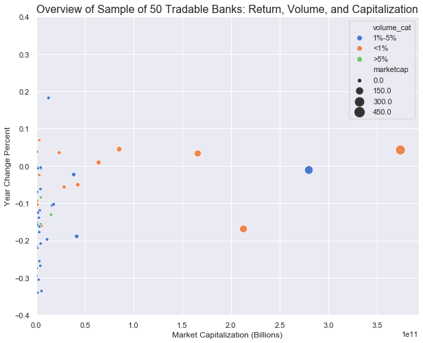

```python
bank_stats.head()
marketCap = bank_stats.marketcap
yearReturn = bank_stats['year1ChangePercent']
volume = bank_stats["volume_cat"]
sns.set(color_codes=True)
sns.set(rc={'figure.figsize': (10, 8)})
sns.scatterplot(x=marketCap, y=yearReturn, hue=volume, palette=sns.color_palette(
    "muted")[:3], size=marketCap/1e9, sizes=(20, 200))
plt.title(
    'Overview of Sample of 50 Tradable Banks: Return, Volume, and Capitalization',
    fontsize=16)
plt.xlabel('Market Capitalization (Billions)')
plt.ylabel('Year Change Percent')
plt.ylim(-0.4, 0.4)
plt.xlim(0, None)
plt.show()
```

## VI. Questions & Analysis

This section contains project questions and analysis. Here you will find the results of a number of hypothesis tests.

### 1. Average Trade Volume Before and After Treatment

> **Question**: Is trading volume different for short vs long-term time periods, approximated by 10-day vs 30-day average volume?

```python
#Calc additional data: 10-day and 30-day volume over market cap ratio in percent:
bank_stats['avg10VolRatio'] = (bank_stats.avg10Volume / bank_stats.marketcap)*100
bank_stats['avg30VolRatio'] = (bank_stats.avg30Volume / bank_stats.marketcap)*100
```

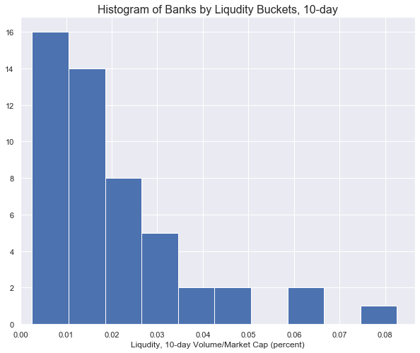

```python
#Clean and inspect data visually, 10-day:
sns.set(rc={'figure.figsize':(10, 8)})
bank_stats.avg10VolRatio.dropna(axis=0, inplace=True)
plt.title('Histogram of Banks by Liqudity Buckets, 10-day', fontsize=16)
plt.xlabel('Liqudity, 10-day Volume/Market Cap (percent)')
bank_stats.avg10VolRatio.hist()
plt.xlim(0, None)
plt.show()
```

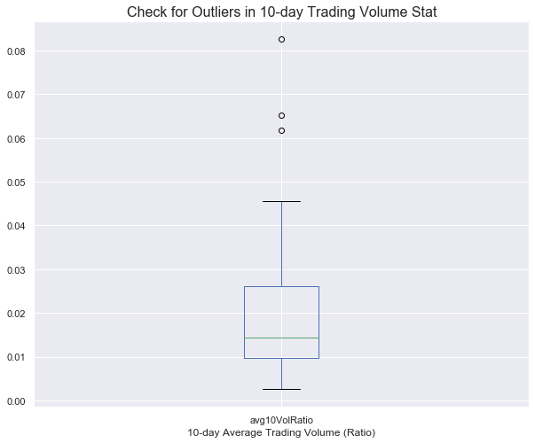

```python
#Check for outliers, 10-day:
bank_stats.boxplot(column = 'avg10VolRatio')
plt.title('Check for Outliers in 10-day Trading Volume Stat', fontsize=16)
plt.xlabel('10-day Average Trading Volume (Ratio)')
plt.show()
```

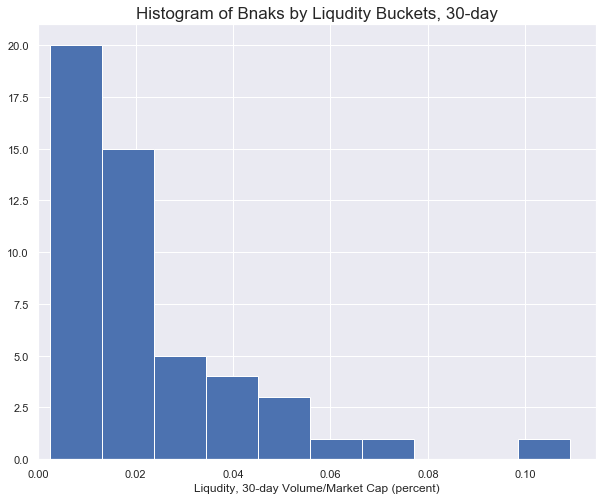

```python
#Clean and inspect data visually, 30-day
sns.set(rc={'figure.figsize':(10, 8)})
bank_stats.avg30VolRatio.dropna(axis=0, inplace=True)
bank_stats.avg30VolRatio.hist()
plt.title('Histogram of Bnaks by Liqudity Buckets, 30-day',
          fontsize=17)
plt.xlabel('Liqudity, 30-day Volume/Market Cap (percent)')
plt.xlim(0, None)
plt.show()
```

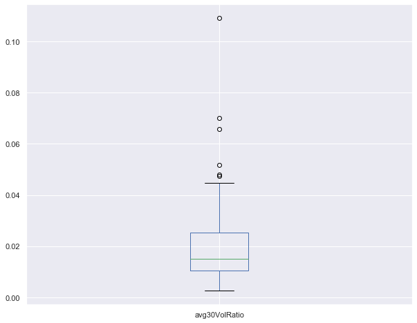

```python
#Check for outliers, 30-day:
sns.set(rc={'figure.figsize':(10, 8)})
bank_stats.boxplot(column = 'avg30VolRatio')
plt.show()
```

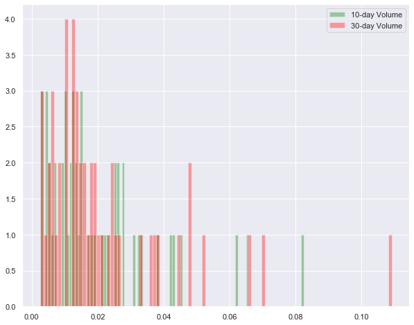

```python
avg10 = bank_stats.avg10VolRatio
avg30 = bank_stats.avg30VolRatio

fig = plt.figure(figsize=(10, 8))
ax = fig.add_subplot(1, 1, 1)
plt.hist(avg10, bins=100, alpha=.35, label='10-day Volume',  color='green')
plt.hist(avg30, bins=100, alpha=.35, label='30-day Volume', color='red')
plt.legend()
plt.show()
```

In order to compare these two groups, we need to perform a a paired t-test. This will compares the means of the group at two different times (e.g., reaction times for the same people on a task before or after a training period). In other words, we use Welch's test for samples assessed at different times, before and after treatment. Just as student's t-test is a useful adaptation of the normal distribution which can lead to better likelihood estimates under certain conditions, the Welch's t-test is a further adaptation that account for additional pertubations in the underlying assumptions of the model. Specifically, the student's t-test assumes that the samples are of equal size and equal variance. When these assumptions are not met, then Welch's t-test provides a more accurate p-value.

#### A. Null & alternative hypothesis

$H_{0}$: The mean difference between the 10-day trade volume and 30-day trade volume variables is zero.

> $$H_{0}: \bar{X}_{10-day-volume} = \bar{X}_{30-day-volume}$$

$H_{a}$: The mean difference between the 10-day trade volume and 30-day trade volume variables is different from zero.

> $$H_{a}: \bar{X}_{10-day-volume} \neq \bar{X}_{30-day-volume}$$

#### B. Choose significance Level

We are performing a 2-tailed t-test.

> Significance level: $\alpha$ = 0.05

#### C. Compute Welche's T

```python
#Welch's Test to compare avgVol/MarcetCap at two different times, using 10-day and 30-day avergages:
import scipy.stats as stats
import numpy as np
#Step 1: compute  welch_t
# avg10 = bank_stats.avg10VolRatio
# avg30 = bank_stats.avg30VolRatio
num1 = avg10.mean() - avg30.mean()
denom1 = np.sqrt(avg10.var(ddof = 1)/len(avg10) + avg30.var(ddof =1)/len(avg30))
welch_t = np.abs(num1/denom1)
print("Critical t: ", welch_t)
```

```
Critical t:  0.44664246343132147
```

#### D. Compute effective degrees of freedom

```python
#Step 2: compute the effective degrees of freedom for 2 samples
s1 = avg10.var(ddof=1)
s2 = avg30.var(ddof=1)
n1 = len(avg10)
n2 = len(avg30)
num2 = (s1/n1 + s2/n2)**2
denom2 = (s1/n1)**2/(n1-1)+(s2/n2)**2/(n2-1)
welch_df = num2/denom2
print("Degrees of freedom: ",welch_df)
```

```
Degrees of freedom:  95.06197033663354
```

#### E. Compute the p-value

```python
#Step 3: compute p-value for the to samples using cdf function from scipy library
p_value = 1-stats.t.cdf(welch_t, welch_df)
print("P-value: ",p_value)
```

```
P-value:  0.32807454019909765
```

#### F. Outcome

Fail to reject the null hypothesis. This indicates that trading volume - adjusted for bank’s size - does not change with time.

### 2. Market Cap Size & P/E Ratio

> **Question**: Is there a significant difference in P/E Ratio between banks with large and small market capitalization?

```python
# drop na value for marketcap
bank_stats.dropna(subset=['marketcap'], inplace=True)
# sort value according to the market cap
bank_stats.sort_values(by=['marketcap'], inplace=True)
# reset index
bank_stats.reset_index(inplace=True)
```

If you take a look at the sample of all 50 Banks, the P/E Ratio mean is around 11.6 with datapoints in both the upper and lower tails of the distribution (as seen below).

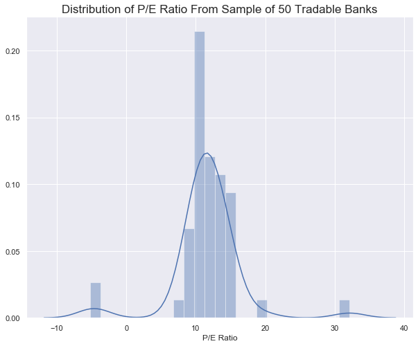

```
P/E Ratio Mean (full sample): 11.6158
```

```python
# plot bank pe distribution
sns.set_context('poster')
sns.set(color_codes=True)
sns.set(rc={'figure.figsize':(10, 8)})
sns.distplot(bank_stats.peRatio) # Blue distribution
plt.title('Distribution of P/E Ratio From Sample of 50 Tradable Banks',
          fontsize=17)
plt.xlabel('P/E Ratio')
plt.show()
# find exact mean of p/e ratio for all 50 banks
full_pemean = bank_stats.peRatio.mean()
print('P/E Ratio Mean (full sample):', full_pemean)
```

Because we are interested in seeing if there is a difference in the p/e ratio for banks with both large and small market cap, we ordered the data by market cap size and split the dataset in half. Our new datasets are small_cap (25 of the banks with lowest market cap) and big_cap (25 of the banks with the highest market cap).

```python
# split the dataset of 50 banks into large and small captilized banks
small_cap = bank_stats.iloc[0:25, :]
big_cap = bank_stats.iloc[25:, :]
```

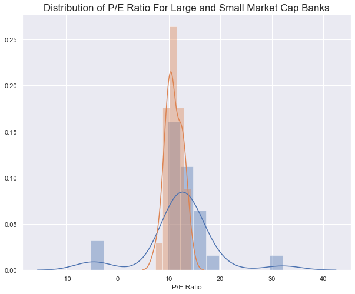

```
small_cap pe ratio mean: 12.243599999999999
big_cap pe ratio mean: 10.987999999999998
```

```python
# PE distributions for small and big market cap banks
sns.set(color_codes=True)
sns.set(rc={'figure.figsize':(10, 8)})
sns.distplot(small_cap.peRatio) # Blue distribution
sns.distplot(big_cap.peRatio) # Orange distribution
plt.title('Distribution of P/E Ratio For Large and Small Market Cap Banks',
          fontsize=17)
plt.xlabel('P/E Ratio')
plt.show()
print('small_cap pe ratio mean:', small_cap.peRatio.mean())
print('big_cap pe ratio mean:', big_cap.peRatio.mean())
```

From the distribution above, we see that banks with small market cap have higher p/e ratio variance. From the above plot, we also see that the p/e ratio mean of small market cap banks is slightly higher than the ratio for big market cap banks (12.24 and 10.99 respectively). This gives us cause to test if the mean p/e ratio for small market cap banks is higher than for large market cap banks.

#### A. Null & alternative hypothesis

$H_{0}$: The mean difference between small market cap and big market cap is zero.

> $$H_{0}: \bar{X}_{high-marketcap} = \bar{X}_{low-marketcap}$$

$H_{a}$: The mean difference for our p/e ratio for small maket cap and big market cap banks is different than zero.

> $$H_{a}: \bar{X}_{high-marketcap} \neq \bar{X}_{low-marketcap}$$

#### B. Choose significance Level

We are performing a 2-tailed t-test.

> Significance level: $\alpha$ = 0.05

#### C. Compute Welche's T

**Note**: the code for the welch_t and compute_pval_singlesided functions can be found in the src/d00_utils folder in hypothesis_testing.py

```python
#Step 1: compute  welch_t
big_cap_pe = big_cap.peRatio
small_cap_pe = small_cap.peRatio
welch_t = welch_ttest(big_cap_pe, small_cap_pe)
print('Critical t-statistic', welch_t)
```

```
Critical t-statistic 0.9065294498918861
```

#### D. Compute degrees of freedom

```python
#Step 2: compute the effective degrees of freedom for 2 samples
dof = len(big_cap_pe) - 1
print('Degrees of Freedom:', dof)
```

```
Degrees of Freedom: 24
```

#### E. Compute the p-value

```python
#Step 3: compute p-value for the to samples using cdf function from scipy library
pval_2sided = compute_pval_singlesided(welch_t, dof)*2
print('P-Value Two-sided:', pval_2sided)
```

```
P-Value Two-sided: 0.37366777579593347
```

#### F. Outcome

Fail to reject the null hypothesis. This indicates smaller banks tend to have higher P/E ratios, but the difference is not significant.

### 3. Market Cap Size & EPS

> **Question**: Is there a significant difference in EPS between banks with large and small market capitalization?

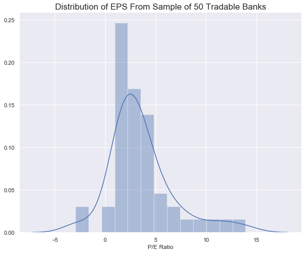

```python
sns.set_context('talk')
sns.set(color_codes=True)
sns.set(rc={'figure.figsize':(10, 8)})
sns.distplot(bank_stats.ttmEPS) # Blue distribution
plt.title('Distribution of EPS From Sample of 50 Tradable Banks',
          fontsize=17)
plt.xlabel('P/E Ratio')
plt.show()
```

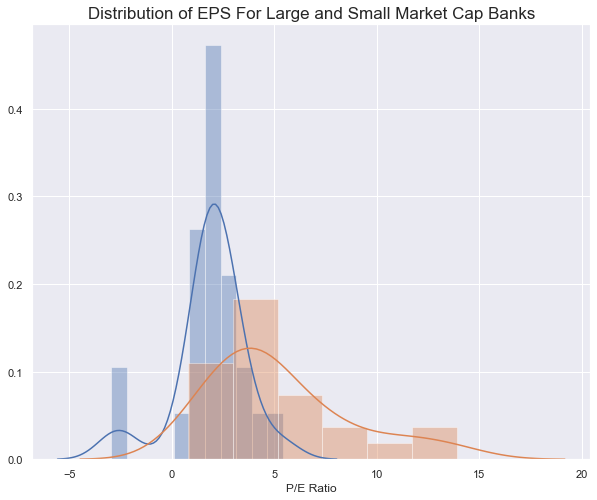

```python
sns.set(color_codes=True)
sns.set(rc={'figure.figsize':(10, 8)})
sns.distplot(small_cap.ttmEPS) # Blue distribution
sns.distplot(big_cap.ttmEPS) # Orange distribution
plt.title('Distribution of EPS For Large and Small Market Cap Banks',
          fontsize=17)
plt.xlabel('P/E Ratio')
plt.show()
```

From the distribution, we see that EPS of banks with larger market capitilization is higher than for those banks with lower market capitilization. This could be interesting to look into.

#### A. Null & alternative hypothesis

$H_{0}$: The mean difference for EPS between small market cap and big market cap is zero.

> $$H_{0}: \bar{X}_{high-marketcap} = \bar{X}_{low-marketcap}$$

$H_{a}$: The mean difference for EPS for small maket cap and big market cap banks is different than zero.

> $$H_{a}: \bar{X}_{high-marketcap} \neq \bar{X}_{low-marketcap}$$

#### B. Choose significance Level

We are performing a 2-tailed t-test.

> **Significance level: $\alpha$ = 0.05**

#### C. Compute Welche's T

```python
#Step 1: compute  welch_t
big_cap_eps = big_cap.ttmEPS
small_cap_eps = small_cap.ttmEPS
welch_t = welch_ttest(big_cap_eps, small_cap_eps)
print('Critical t-statistic', welch_t)
```

```
Critical t-statistic 4.379282409694953
```

#### D. Compute degrees of freedom

```python
#Step 2: compute the effective degrees of freedom for 2 samples
dof = len(big_cap_eps) - 1
print('Degrees of Freedom:', dof)
```

```
Degrees of Freedom: 24
```

```python
#Step 3: compute p-value for the to samples using cdf function from scipy library
pval_2sided = compute_pval_singlesided(welch_t, dof)*2
print('P-Value Two-sided:', pval_2sided)
```

```
P-Value Two-sided: 0.00020134426405737926
```

#### E. Outcome

Reject the null hypothesis. This indicates that smaller banks tend to have lower EPS and the difference is significant.

## VII. Conclusion

- Trading volume adjusted for bank’s size does not change with time.
- Smaller banks tend to have higher PE ratios, but the difference is not significant.
- Smaller banks also tend to have lower EPS and the difference is significant.